# 4.10 Coding Etiquette & Excel Reporting

### **Step 1:** Import libraries and datsets

```python
# Import libraries
import pandas as pd
import numpy as np
import os
import matplotlib.pyplot as plt
import seaborn as sns
import scipy

# Create path - Shortcut for Importing Data Files
path = r'C:\Users\sanch\Documents\Instacart Basket Analysis'

# Import ords_prods_merge.pkl dataset
df_1 = pd.read_pickle(os.path.join(path, '02 Data', 'Prepared Data', 'merge.pkl'))
```

```python
cols = ['loyalty_flag', 'spending_flag', 'frequency_flag']

for col in cols:
    print(f"\nFrequency for {col}:")
    print(df_1[col].value_counts())
```

```
Frequency for loyalty_flag:
loyalty_flag
Regular customer    17870801
New customer        12079192
Loyal customer       2454866
Name: count, dtype: int64

Frequency for spending_flag:
spending_flag
Low spender     31770614
High spender      634245
Name: count, dtype: int64

Frequency for frequency_flag:
frequency_flag
Frequent customer        21559853
Regular customer          7208564
Non-frequent customer     3636437
Name: count, dtype: int64
```

#### Observations: Confirm the assumptions about missing values in 'days_since_prior_order' in Task 4.5 that those missing values are related to first orders.

```python
# Create a crosstab between 'days_since_prior_order' and 'order_number' for data checks
crosstab = pd.crosstab(df_1['days_since_prior_order'], df_1['order_number'], dropna = False)
```

```python
# For easier copying into Excel
crosstab.to_clipboard()
```

```python
crosstab.head()
```

| order_number days_since_prior_order | 1 | 2 | 3 | 4 | 5 | 6 | 7 | 8 | 9 | 10 | ... | 90 | 91 | 92 | 93 | 94 | 95 | 96 | 97 | 98 | 99 |
| --- | --- | --- | --- | --- | --- | --- | --- | --- | --- | --- | --- | --- | --- | --- | --- | --- | --- | --- | --- | --- | --- |
| 0.0 | 0 | 20536 | 20441 | 17984 | 16438 | 16046 | 14384 | 13890 | 12774 | 11460 | ... | 1195 | 1148 | 1040 | 937 | 1134 | 1099 | 1041 | 883 | 1037 | 935 |
| 1.0 | 0 | 31674 | 29950 | 28010 | 27092 | 25533 | 24996 | 22921 | 21783 | 21067 | ... | 2787 | 2801 | 2728 | 2605 | 2606 | 2639 | 2436 | 2535 | 2633 | 2363 |
| 2.0 | 0 | 46454 | 46264 | 43902 | 40729 | 40907 | 38101 | 37519 | 35745 | 33830 | ... | 3623 | 3555 | 3314 | 3589 | 3319 | 3072 | 2985 | 3057 | 3091 | 2609 |
| 3.0 | 0 | 61637 | 63388 | 59996 | 57882 | 56183 | 52869 | 49291 | 48295 | 47826 | ... | 3318 | 3237 | 2799 | 3073 | 2902 | 2635 | 2658 | 2462 | 2168 | 2467 |
| 4.0 | 0 | 76733 | 78861 | 73540 | 70519 | 66569 | 62399 | 61143 | 59499 | 57700 | ... | 2342 | 2260 | 2490 | 2031 | 1800 | 2083 | 1918 | 1792 | 1695 | 1810 |

5 rows × 99 columns

#### We found missing values in this column but conducted an analysis that revealed them to be fine in context. Please confirm whether our assumption is correct.

### **Step 2:** PII check

This dataset contains 'first_name' and 'surname' columns, which need to be removed for protecing customers' privacy. Also, this dataset contains some personal information such as (income, age, etc.). This dataset will only be accessed by authorized personel within the company and any presentations or reports will use aggregated insights without exposing individual personal details.

```python
df_1.columns
```

```
Index(['user_id', 'first_name', 'surname', 'gender', 'state', 'age',
       'date_joined', 'number_of_dependents', 'family_status', 'income',
       'order_id', 'order_number', 'orders_day_of_week', 'order_hour_of_day',
       'days_since_prior_order', 'product_id', 'add_to_cart_order',
       'reordered', 'product_name', 'aisle_id', 'department_id', 'prices',
       'price_range_loc', 'busiest day', 'busiest days',
       'busiest_period_of_day', 'avg_order', 'loyalty_flag', 'avg_prices',
       'spending_flag', 'median_days_prior', 'frequency_flag', '_merge'],
      dtype='object')
```

```python
df = df_1.drop(['first_name', 'surname'], axis = 1)
```

```python
df.columns
```

```
Index(['user_id', 'gender', 'state', 'age', 'date_joined',
       'number_of_dependents', 'family_status', 'income', 'order_id',
       'order_number', 'orders_day_of_week', 'order_hour_of_day',
       'days_since_prior_order', 'product_id', 'add_to_cart_order',
       'reordered', 'product_name', 'aisle_id', 'department_id', 'prices',
       'price_range_loc', 'busiest day', 'busiest days',
       'busiest_period_of_day', 'avg_order', 'loyalty_flag', 'avg_prices',
       'spending_flag', 'median_days_prior', 'frequency_flag', '_merge'],
      dtype='object')
```

### **Step 3.1:** Create a 'Region' column based on the 'State' column

```python
# 1. Full name -> abbreviation
state_abbr = {
    'Alabama': 'AL', 'Alaska': 'AK', 'Arizona': 'AZ', 'Arkansas': 'AR', 'California': 'CA',
    'Colorado': 'CO', 'Connecticut': 'CT', 'Delaware': 'DE', 'District of Columbia': 'DC',
    'Florida': 'FL', 'Georgia': 'GA', 'Hawaii': 'HI', 'Idaho': 'ID', 'Illinois': 'IL',
    'Indiana': 'IN', 'Iowa': 'IA', 'Kansas': 'KS', 'Kentucky': 'KY', 'Louisiana': 'LA',
    'Maine': 'ME', 'Maryland': 'MD', 'Massachusetts': 'MA', 'Michigan': 'MI', 'Minnesota': 'MN',
    'Mississippi': 'MS', 'Missouri': 'MO', 'Montana': 'MT', 'Nebraska': 'NE', 'Nevada': 'NV',
    'New Hampshire': 'NH', 'New Jersey': 'NJ', 'New Mexico': 'NM', 'New York': 'NY',
    'North Carolina': 'NC', 'North Dakota': 'ND', 'Ohio': 'OH', 'Oklahoma': 'OK', 'Oregon': 'OR',
    'Pennsylvania': 'PA', 'Rhode Island': 'RI', 'South Carolina': 'SC', 'South Dakota': 'SD',
    'Tennessee': 'TN', 'Texas': 'TX', 'Utah': 'UT', 'Vermont': 'VT', 'Virginia': 'VA',
    'Washington': 'WA', 'West Virginia': 'WV', 'Wisconsin': 'WI', 'Wyoming': 'WY'
}
```

```python
# 2. Abbreviation -> Region
region_map = {
    # Northeast
    'CT': 'Northeast', 'ME': 'Northeast', 'MA': 'Northeast', 'NH': 'Northeast', 'RI': 'Northeast', 'VT': 'Northeast',
    'NJ': 'Northeast', 'NY': 'Northeast', 'PA': 'Northeast',
    # Midwest
    'IL': 'Midwest', 'IN': 'Midwest', 'MI': 'Midwest', 'OH': 'Midwest', 'WI': 'Midwest',
    'IA': 'Midwest', 'KS': 'Midwest', 'MN': 'Midwest', 'MO': 'Midwest', 'NE': 'Midwest', 'ND': 'Midwest', 'SD': 'Midwest',
    # South
    'DE': 'South', 'FL': 'South', 'GA': 'South', 'MD': 'South', 'NC': 'South', 'SC': 'South', 'VA': 'South',
    'DC': 'South', 'WV': 'South', 'AL': 'South', 'KY': 'South', 'MS': 'South', 'TN': 'South',
    'AR': 'South', 'LA': 'South', 'OK': 'South', 'TX': 'South',
    # West
    'AZ': 'West', 'CO': 'West', 'ID': 'West', 'MT': 'West', 'NV': 'West', 'NM': 'West', 'UT': 'West', 'WY': 'West',
    'AK': 'West', 'CA': 'West', 'HI': 'West', 'OR': 'West', 'WA': 'West'
}
```

```python
# 3. Apply transformations
df['state_abbr'] = df['state'].map(state_abbr)
df['region'] = df['state_abbr'].map(region_map)

# 4. Check results
df[['state', 'state_abbr', 'region']].drop_duplicates().sort_values('state').head()
```

|  | state | state_abbr | region |
| --- | --- | --- | --- |
| 14894 | Alabama | AL | South |
| 2678 | Alaska | AK | West |
| 6254 | Arizona | AZ | West |
| 2808 | Arkansas | AR | South |
| 4720 | California | CA | West |

### **Step 3.2:** Determine whether there’s a difference in spending habits between the different regions

```python
df['loyalty_flag'].value_counts()
```

```
loyalty_flag
Regular customer    17870801
New customer        12079192
Loyal customer       2454866
Name: count, dtype: int64
```

```python
pivot_table_1 = pd.pivot_table(df, values='prices', index= 'region', columns= 'loyalty_flag', aggfunc='mean')
print(pivot_table_1)
```

```
loyalty_flag  Loyal customer  New customer  Regular customer
region
Midwest            10.681094     13.757217         12.272273
Northeast          12.112877     12.659614         10.744030
South              12.185113     13.762819         11.133253
West                9.057475     12.759760         10.665151
```

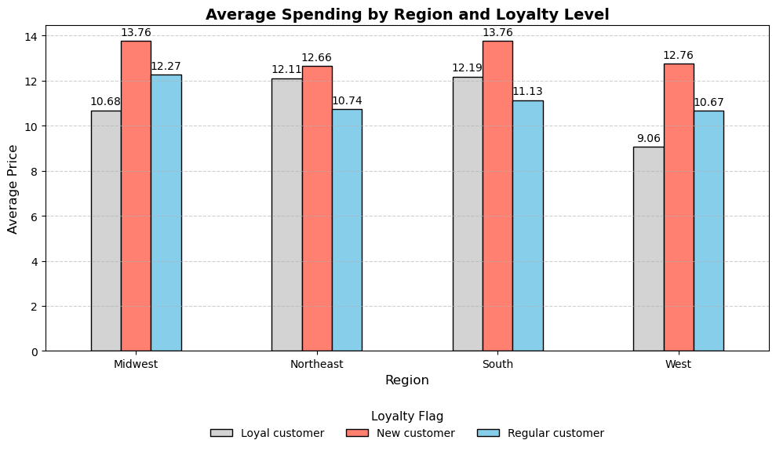

```python
# Plot
ax_1 = pivot_table_1.plot(kind='bar', figsize=(10, 6), color= ['#d3d3d3', '#ff7f70', '#87CEEB'], edgecolor='black')

# Titles and labels
plt.title('Average Spending by Region and Loyalty Level', fontsize=14, fontweight='bold')
plt.xlabel('Region', fontsize=12)
plt.ylabel('Average Price', fontsize=12)
plt.xticks(rotation=0)

# Legend at the bottom
plt.legend(
    title='Loyalty Flag',
    title_fontsize=11,
    fontsize=10,
    loc='lower center',
    bbox_to_anchor=(0.5, -0.3),
    ncol=3,
    frameon=False
)

# Value labels on bars
for container in ax_1.containers:
    ax_1.bar_label(container, fmt='%.2f', label_type='edge', fontsize=10, padding=3)

# Grid & layout
plt.grid(axis='y', linestyle='--', alpha=0.6)
plt.tight_layout()
plt.savefig('/Users/sanch/Documents/Instacart Basket Analysis/04 Analysis/Visualisations/bar_avg_spending_region_loyalty.png')
```

### **Step 4:** Create an exclusion flag for low-activity customers

```python
# Create exclusion flag for low-activity customers (less than 5 orders total)
df['exclusion_flag'] = df['order_number'] < 5

# Check the number of active and low-active customers
df['exclusion_flag'].value_counts()
```

```
exclusion_flag
False    24414877
True      7989982
Name: count, dtype: int64
```

```python
# Filter only active customers (who placed 5 or more orders)
df_active = df[df['exclusion_flag'] == False]

# Quick check
df_active['user_id'].nunique()
```

```
162631
```

```python
# Save active users data
df_active.to_pickle('/Users/sanch/Documents/Instacart Basket Analysis/02 Data/Prepared Data/df_active_customers.pkl')
```

### **Step 5:** Create a Profiling Variable

```python
df['income'].describe()
```

```
count    3.240486e+07
mean     9.943773e+04
std      4.305727e+04
min      2.590300e+04
25%      6.700400e+04
50%      9.661800e+04
75%      1.279120e+05
max      5.939010e+05
Name: income, dtype: float64
```

```python
df['number_of_dependents'].describe()
```

```
count    3.240486e+07
mean     1.501896e+00
std      1.118865e+00
min      0.000000e+00
25%      1.000000e+00
50%      2.000000e+00
75%      3.000000e+00
max      3.000000e+00
Name: number_of_dependents, dtype: float64
```

```python
def profile_segment(row):
    if row['number_of_dependents'] >= 2 and row['income'] > 120000:
        return 'Parent, High Income'
    elif row['number_of_dependents'] >= 2:
        return 'Parent, Low/Med Income'
    elif row['number_of_dependents'] == 0 and row['age'] < 35:
        return 'Young Adult, No Kids'
    elif row['number_of_dependents'] == 0 and row['age'] >= 35:
        return 'Older Adult, No Kids'
    else:
        return 'Other'

# Apply to df_active
df_active['profile_segment'] = df_active.apply(profile_segment, axis=1)

# Quick check
df_active['profile_segment'].value_counts(dropna=False)
```

```
profile_segment
Parent, Low/Med Income    8602905
Other                     6082107
Older Adult, No Kids      4482917
Parent, High Income       3624863
Young Adult, No Kids      1622085
Name: count, dtype: int64
```

### **Step 6:** Create a Visualization for Profile Segments

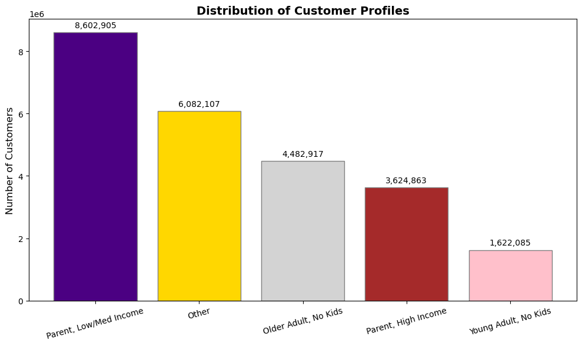

```python
# Set color palette
colors = ['#4b0082', '#ffd700', '#d3d3d3', '#a52a2a', '#ffc0cb']

# Prepare data
profile_counts = df_active['profile_segment'].value_counts(dropna=False)

# Plotting
plt.figure(figsize=(10, 6))
bars = plt.bar(profile_counts.index, profile_counts.values, color=colors, edgecolor='grey')

# Add value labels on top of bars
for bar in bars:
    yval = bar.get_height()
    plt.text(bar.get_x() + bar.get_width()/2, yval + 100000, f'{yval:,.0f}',
             ha='center', va='bottom', fontsize=10)

# Styling
plt.title('Distribution of Customer Profiles', fontsize=14, weight='bold')
plt.ylabel('Number of Customers', fontsize=12)
plt.xticks(rotation=15)
plt.tight_layout()

# Save figure
plt.savefig('/Users/sanch/Documents/Instacart Basket Analysis/04 Analysis/Visualisations/bar_profile.png')
plt.show()
```

**Observation:** The majority of customers were low- and medium-income parents, while young adults without children were the least frequent shoppers.

### **Step 7:** Aggregate the max, mean, and min variables on a customer-profile level for order numbers and prices.

```python
agg_profile = df_active.groupby('profile_segment').agg({'order_number': ['max', 'mean', 'min'],'prices': ['max', 'mean', 'min']})
```

```python
agg_profile
```

| profile_segment | order_number max | order_number mean | order_number min | prices max | prices mean | prices min |
| --- | --- | --- | --- | --- | --- | --- |
| Older Adult, No Kids | 99 | 22.191458 | 5 | 99999.0 | 11.895191 | 1.0 |
| Other | 99 | 21.911415 | 5 | 99999.0 | 11.510665 | 1.0 |
| Parent, High Income | 99 | 21.901597 | 5 | 99999.0 | 20.274673 | 1.0 |
| Parent, Low/Med Income | 99 | 21.891518 | 5 | 99999.0 | 8.351155 | 1.0 |
| Young Adult, No Kids | 99 | 21.844133 | 5 | 99999.0 | 12.402147 | 1.0 |

**Observation:** There was no clear difference in the number of orders across customer profiles. However, high-income parents demonstrated a greater willingness to purchase higher-priced items compared with other groups. In contrast, low- and medium-income parents appeared more budget-conscious, showing more cautious spending patterns than their counterparts.

### **Step 8_1:** Compare customer profiles with regions.

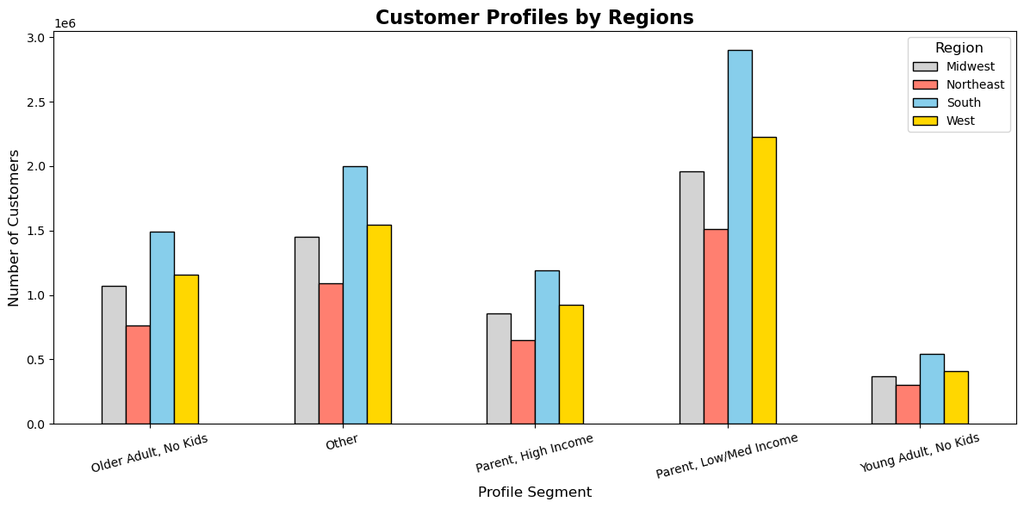

```python
# Set color palette
colors_1 = ['#d3d3d3', '#ff7f70', '#87ceeb', '#ffd700']

# Cross-tab for profile vs region
crosstab_2 = pd.crosstab(df_active['profile_segment'], df_active['region'])

# Plot with enhancements
ax_2 = crosstab_2.plot(kind='bar', figsize=(12, 6), color=colors_1, edgecolor='black')

# Title and axis labels
plt.title('Customer Profiles by Regions', fontsize=16, fontweight='bold')
plt.xlabel('Profile Segment', fontsize=12)
plt.ylabel('Number of Customers', fontsize=12)
plt.xticks(rotation=15, fontsize=10)
plt.yticks(fontsize=10)

# Legend formatting
plt.legend(title='Region', title_fontsize=12, fontsize=10, loc='upper right')

# Layout and save
plt.tight_layout()
plt.savefig('/Users/sanch/Documents/Instacart Basket Analysis/04 Analysis/Visualisations/bar_region_profile.png')
plt.show()
```

**Observation:** The majority of customers were located in the South, followed by the West, Midwest, and Northeast. The distribution of customer profiles was relatively consistent across regions. Low- and medium-income parents were the most frequent shoppers, followed by parents with one child, while young adults without children shopped the least often.

### **Step 8_2:** Compare customer profiles with departments

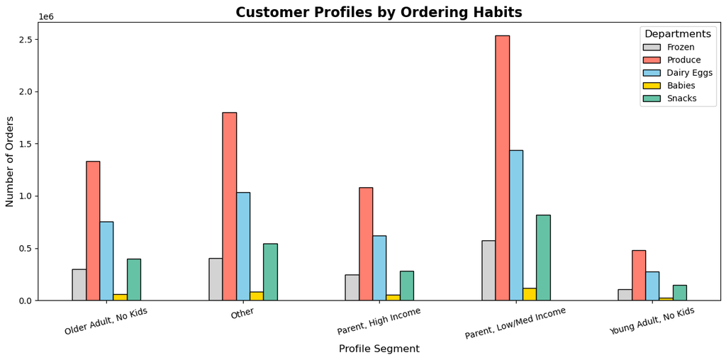

```python
# Set color palette
colors_2 = ['#d3d3d3', '#ff7f70', '#87ceeb', '#ffd700', '#66c2a5']

# Cross-tab for profile vs ordering habits
crosstab_3 = pd.crosstab(df_active['profile_segment'], df_active['department_id'])

# Filter only departments
crosstab_3 = crosstab_3[[1,4,16,18,19]]

# Plot with enhancements
ax_3 = crosstab_3.plot(kind='bar', figsize=(12, 6), color=colors_2, edgecolor='black')

# Title and axis labels
plt.title('Customer Profiles by Ordering Habits', fontsize=16, fontweight='bold')
plt.xlabel('Profile Segment', fontsize=12)
plt.ylabel('Number of Orders', fontsize=12)
plt.xticks(rotation=15, fontsize=10)
plt.yticks(fontsize=10)

# Legend formatting
plt.legend(title='Departments', labels=["Frozen", "Produce", "Dairy Eggs", "Babies", "Snacks"], title_fontsize=12, fontsize=10, loc='upper right')

# Layout and save
plt.tight_layout()
plt.savefig('/Users/sanch/Documents/Instacart Basket Analysis/04 Analysis/Visualisations/bar_department_profile.png')
plt.show()
```

**Observation:** For categories such as frozen foods, produce, dairy and eggs, baby products, and snacks, low- and medium-income parents demonstrated the greatest purchasing power.

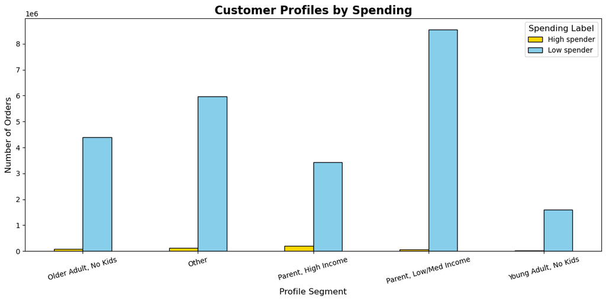

```python
# Set color palette
colors_3 = ['#ffd700','#87ceeb']

# Cross-tab for profile vs ordering habits
crosstab_4 = pd.crosstab(df_active['profile_segment'], df_active['spending_flag'])

# Plot with enhancements
ax_3 = crosstab_4.plot(kind='bar', figsize=(12, 6), color=colors_3, edgecolor='black')

# Title and axis labels
plt.title('Customer Profiles by Spending', fontsize=16, fontweight='bold')
plt.xlabel('Profile Segment', fontsize=12)
plt.ylabel('Number of Orders', fontsize=12)
plt.xticks(rotation=15, fontsize=10)
plt.yticks(fontsize=10)

# Legend formatting
plt.legend(title='Spending Label', title_fontsize=12, fontsize=10, loc='upper right')

# Layout and save
plt.tight_layout()
plt.savefig('/Users/sanch/Documents/Instacart Basket Analysis/04 Analysis/Visualisations/bar_spend_profile.png')
plt.show()
```

**Observation:** The majority of customers tended to low spenders. But parents with high income were more likely to be high spenders than other groups.

```python
df_active.columns
```

```
Index(['user_id', 'gender', 'state', 'age', 'date_joined',
       'number_of_dependents', 'family_status', 'income', 'order_id',
       'order_number', 'orders_day_of_week', 'order_hour_of_day',
       'days_since_prior_order', 'product_id', 'add_to_cart_order',
       'reordered', 'product_name', 'aisle_id', 'department_id', 'prices',
       'price_range_loc', 'busiest day', 'busiest days',
       'busiest_period_of_day', 'avg_order', 'loyalty_flag', 'avg_prices',
       'spending_flag', 'median_days_prior', 'frequency_flag', '_merge',
       'state_abbr', 'region', 'exclusion_flag', 'profile_segment'],
      dtype='object')
```

### **Step 9:** Create a heatmap between 'orders_day_of_week' and 'profile_segment'

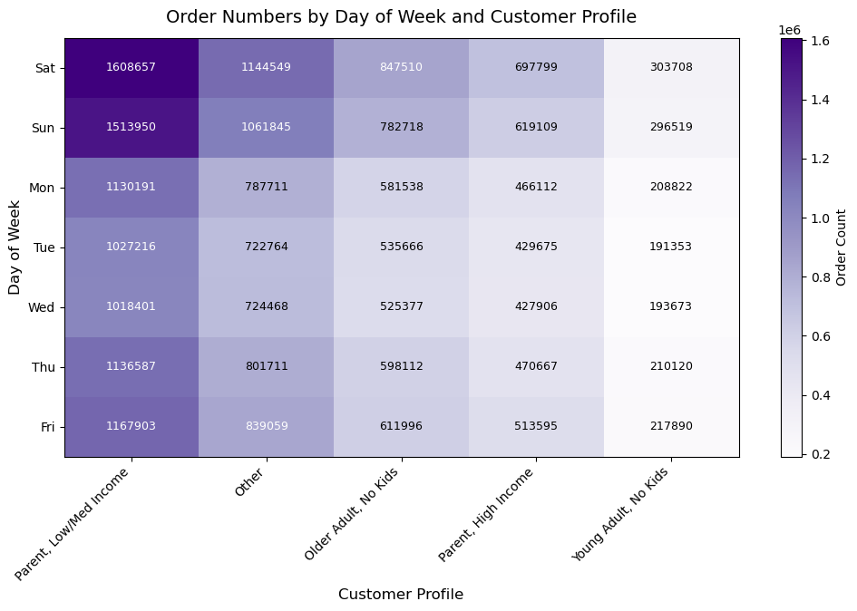

```python
crosstab_5 = pd.crosstab(df_active['orders_day_of_week'], df_active['profile_segment'])

profile_order = crosstab_5.sum(axis=0).sort_values(ascending=False).index.tolist()
crosstab_5 = crosstab_5[profile_order]

day_labels_map = {0:"Sat", 1:"Sun", 2:"Mon", 3:"Tue", 4:"Wed", 5:"Thu", 6:"Fri"}
crosstab_5.index = pd.to_numeric(crosstab_5.index)
y_ticklabels = [day_labels_map.get(v, str(v)) for v in crosstab_5.index]

fig, ax = plt.subplots(figsize=(12, 6))
im = ax.imshow(crosstab_5.values, aspect="auto", cmap="Purples")

ax.set_title("Order Numbers by Day of Week and Customer Profile", fontsize=14, pad=12)
ax.set_xlabel("Customer Profile", fontsize=12)
ax.set_ylabel("Day of Week", fontsize=12)

ax.set_xticks(np.arange(crosstab_5.shape[1]))
ax.set_xticklabels(crosstab_5.columns, rotation=45, ha="right")

ax.set_yticks(np.arange(crosstab_5.shape[0]))
ax.set_yticklabels(y_ticklabels)

vals = crosstab_5.values
threshold = vals.max() / 2

for i in range(vals.shape[0]):
    for j in range(vals.shape[1]):
        color = "white" if vals[i, j] > threshold else "black"
        ax.text(j, i, f"{int(vals[i, j])}", ha="center", va="center", color=color, fontsize=9)

cbar = fig.colorbar(im, ax=ax)
cbar.set_label("Order Count", rotation=90)

# --- Save BEFORE showing ---
outdir = '/Users/sanch/Documents/Instacart Basket Analysis/04 Analysis/Visualisations'
os.makedirs(outdir, exist_ok=True)
outfile = os.path.join(outdir, 'heatmap_customer_day.png')
fig.savefig(outfile, dpi=300, bbox_inches='tight')

# --- Save BEFORE showing ---
outdir = '/Users/sanch/Documents/Instacart Basket Analysis/04 Analysis/Visualisations'
os.makedirs(outdir, exist_ok=True)
outfile = os.path.join(outdir, 'heatmap_customer_day.png')
fig.savefig(outfile, dpi=300, bbox_inches='tight')
```

**Observation:** Most orders were placed on Saturdays and Sundays by low- and medium-income parents. In contrast, Tuesdays and Wednesdays saw the fewest orders across all customer profiles.

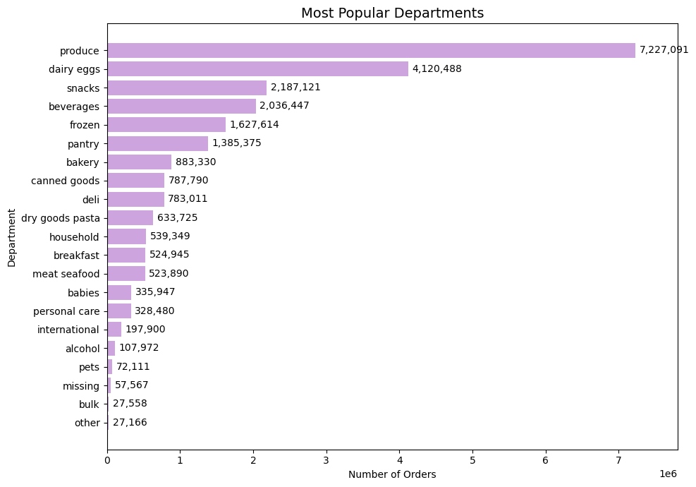

```python
# Map IDs to names
dept_map = {
    1: "frozen",
    2: "other",
    3: "bakery",
    4: "produce",
    5: "alcohol",
    6: "international",
    7: "beverages",
    8: "pets",
    9: "dry goods pasta",
    10: "bulk",
    11: "personal care",
    12: "meat seafood",
    13: "pantry",
    14: "breakfast",
    15: "canned goods",
    16: "dairy eggs",
    17: "household",
    18: "babies",
    19: "snacks",
    20: "deli",
    21: "missing"
}

df_active["department_name"] = df_active["department_id"].map(dept_map)

# Counts (descending so the most popular are at the top)
dept_counts = df_active["department_name"].value_counts().sort_values(ascending=True)

# Plot
fig, ax = plt.subplots(figsize=(10, 7))
bars = ax.barh(dept_counts.index, dept_counts.values, color='#CDA4DE')

# Value labels at end of bars
ax.bar_label(bars, fmt="{:,.0f}", padding=4)

# Titles & labels
ax.set_title("Most Popular Departments", fontsize=14)
ax.set_xlabel("Number of Orders")
ax.set_ylabel("Department")

# Nice margins on x so labels don’t clip
ax.set_xlim(0, dept_counts.values.max() * 1.08)

plt.tight_layout()
plt.savefig('/Users/sanch/Documents/Instacart Basket Analysis/04 Analysis/Visualisations/bar_department.png')
```